# Practice with dplyr and ggplot2

Angelica Gamboa

DATA 2401

## Fancy Histograms!

We’ll start by making some histograms.

```r
# install.packages("dslabs")
library(dslabs)
data(heights)
glimpse(heights)
```

```
## Rows: 1,050
## Columns: 2
## $ sex    <fct> Male, Male, Male, Male, Male, Female, Female, Female, Female, M…
## $ height <dbl> 75, 70, 68, 74, 61, 65, 66, 62, 66, 67, 72, 72, 69, 68, 69, 66,…
```

This data is the heights of humans, divided by their biological sex.

Use ggplot to make a histogram of all of the heights:

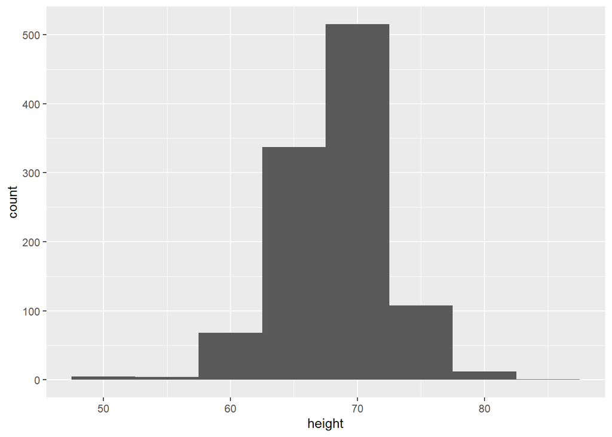

```r
h <- ggplot(heights, aes(x = height))
h + geom_histogram(binwidth = 5)
```

Change up the binwidth and see how the plots change. Try 1, 5, 10, and 20

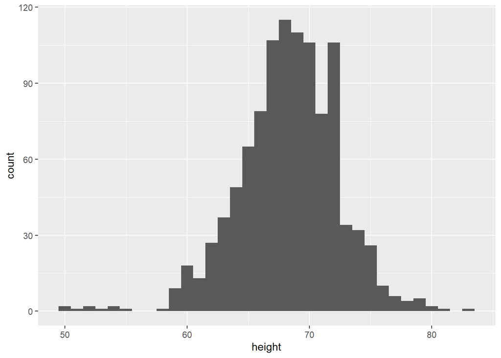

```r
h <- ggplot(heights, aes(x = height))
h + geom_histogram(binwidth = 1)
```

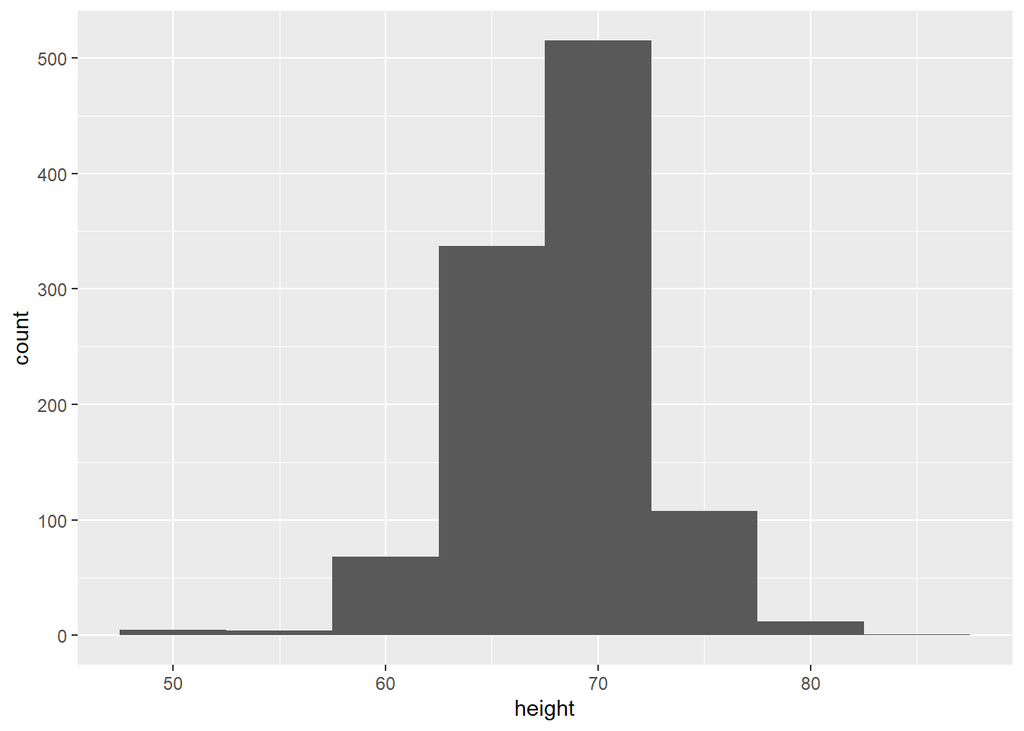

```r
h <- ggplot(heights, aes(x = height))
h + geom_histogram(binwidth = 5)
```

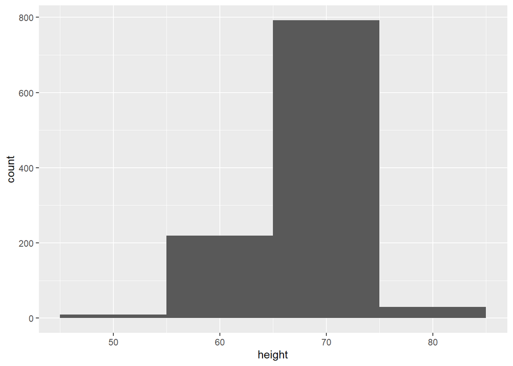

```r
h <- ggplot(heights, aes(x = height))
h + geom_histogram(binwidth = 10)
```

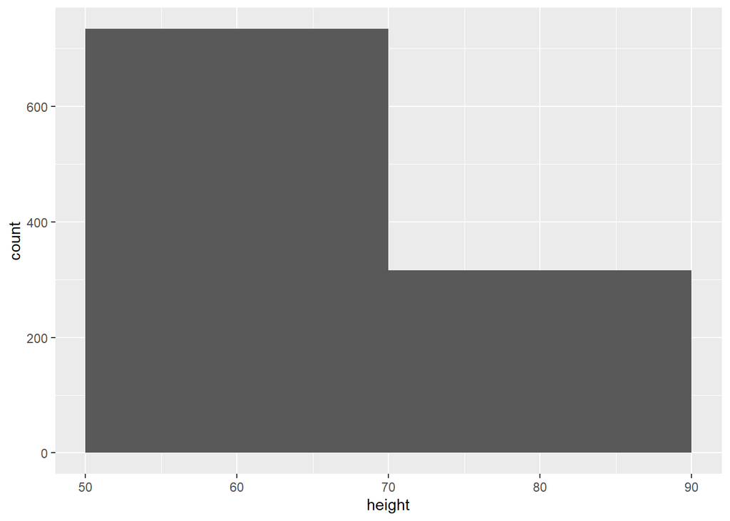

```r
h <- ggplot(heights, aes(x = height))
h + geom_histogram(binwidth = 20)
```

Smooth this out to an emperical density with `geom_density()`

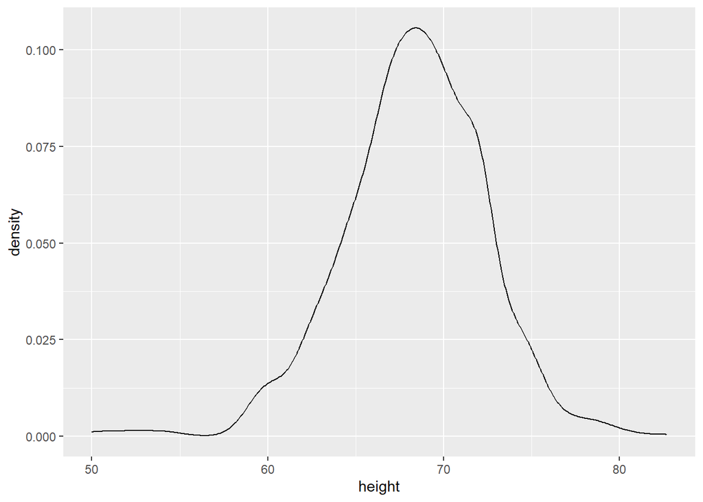

```r
h <- ggplot(heights, aes(x = height))
h + geom_density()
```

Use a new argument in the `aes()`, `group =` to split this density by sex

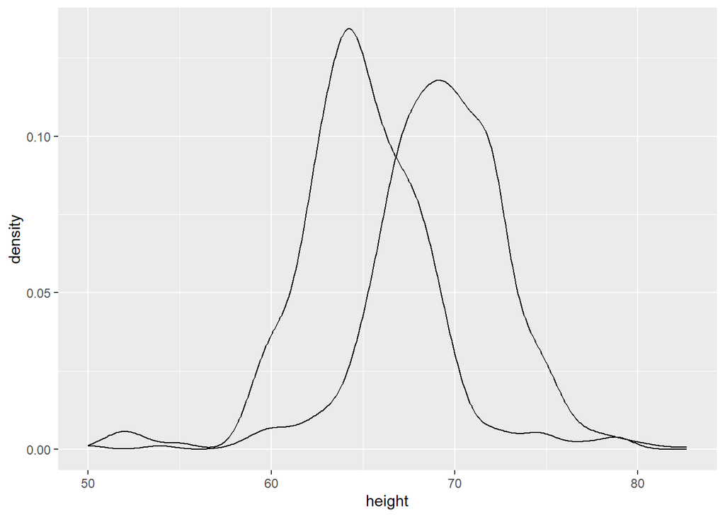

```r
h <- ggplot(heights, aes(x = height, group = sex))
h + geom_density()
```

OR we can do it with `color` or `fill.` If you say you want to color by sex, R knows that you want a different curve for each of them.

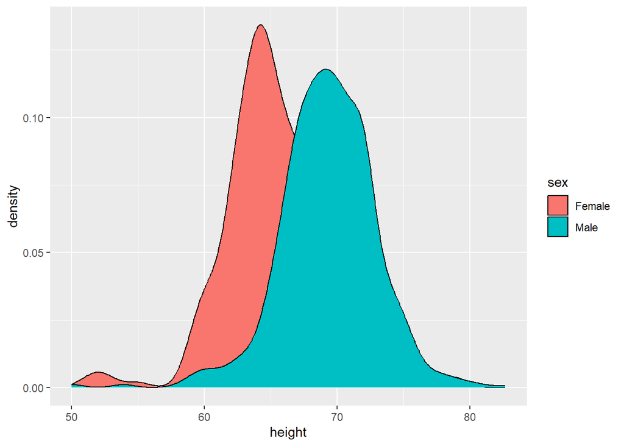

```r
h <- ggplot(heights, aes(x = height, fill = sex))
h + geom_density()
```

If you’ve used fill, then there is now a slight issue that they are overlapped. We can fix this with alpha transparency!

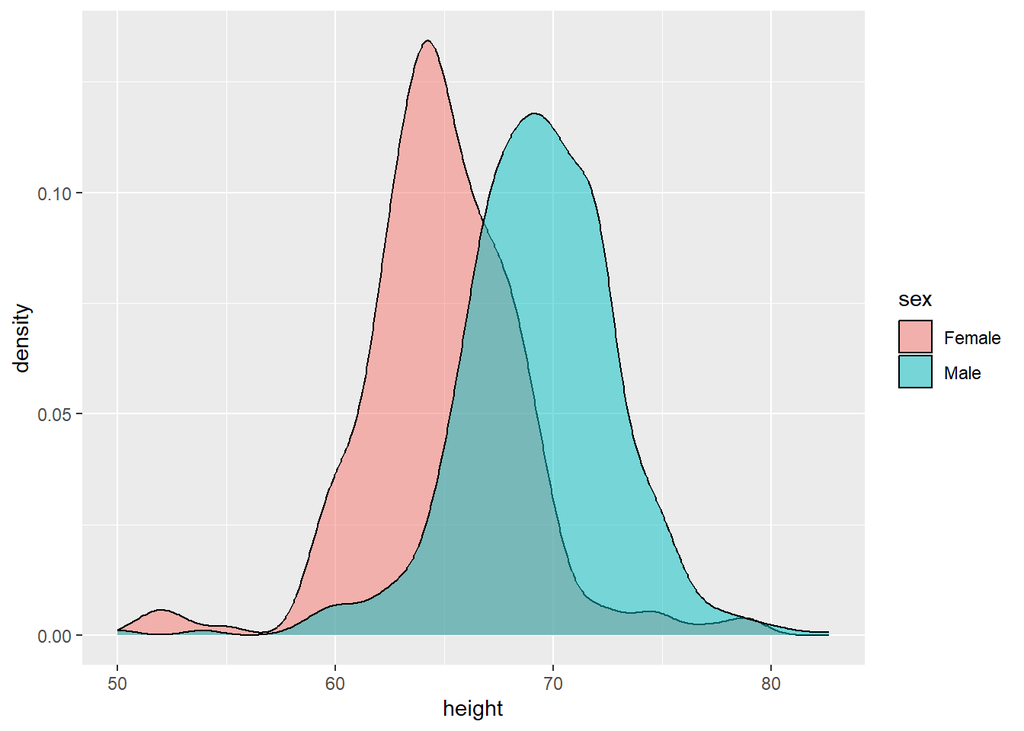

```r
h + geom_density(alpha = 1/2 ,size = 1/2)
```

Let’s make some boxplots of the same information.

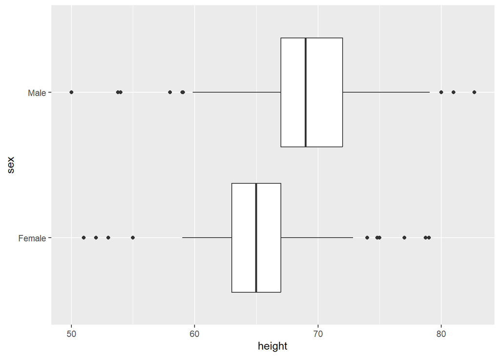

```r
ggplot(heights, aes(x=height, y = sex)) +
  geom_boxplot()
```

## Quantatitive summaries:

Find the mean and median overall.

```r
mean(heights$height)
```

```
## [1] 68.32301
```

```r
median(heights$height)
```

```
## [1] 68.5
```

Find the mean and median for both groups.

```r
male <- heights %>%
  filter(sex == "Male") %>%
  summarize(mean_male_height = mean(height), median_male_height = median(height))

female <- heights %>%
  filter(sex == "Female") %>%
  summarize(mean_female_height = mean(height), median_female_height = median(height))

female
```

```
##   mean_female_height median_female_height
## 1           64.93942             64.98031
```

```r
male
```

```
##   mean_male_height median_male_height
## 1         69.31475                 69
```

```r
max_height <- heights %>%
  filter(sex == "Female") %>%
  summarize(tallest_woman = max(height))
max_height
```

```
##   tallest_woman
## 1            79
```

## Presidental Elections Data

```r
# install.packages("pscl")
library(pscl) # loads in the package that has this data.
## You might need to install this...

# data for presidental elections
votedata <-  presidentialElections
glimpse(votedata)
```

```
## Rows: 1,097
## Columns: 4
## $ state   <chr> "Alabama", "Arizona", "Arkansas", "California", "Colorado", "C…
## $ demVote <dbl> 84.76, 67.03, 86.27, 58.41, 54.81, 47.40, 48.11, 74.49, 91.60,…
## $ year    <int> 1932, 1932, 1932, 1932, 1932, 1932, 1932, 1932, 1932, 1932, 19…
## $ south   <lgl> TRUE, FALSE, TRUE, FALSE, FALSE, FALSE, FALSE, TRUE, TRUE, FAL…
```

Let’s look at the democratic vote by state for 2000. We can’t use `geom_bar` for a bar chart, since we have the category in one variable and the “height” of the bar in another. We need `geom_col()`

Make a bar graph of the democratic vote by state in 2000.

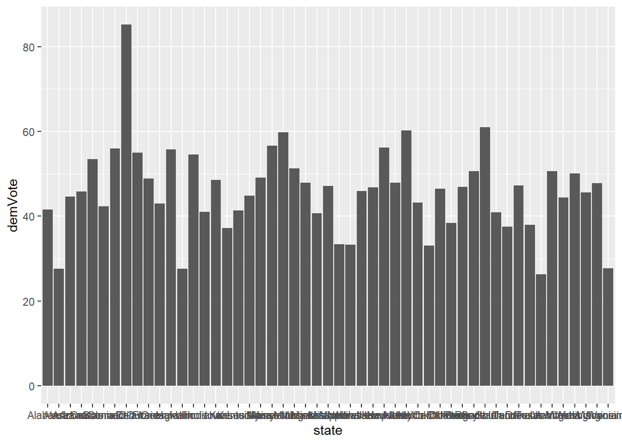

```r
ggplot(data = votedata %>% filter(year == 2000)) +
  geom_col(aes(x = state, y = demVote))
```

Well this looks awful. We have two options: swap the x and y or the more fun sounding… Coordinate flip!

Use `coord_flip()` on the previous graph to make it better.

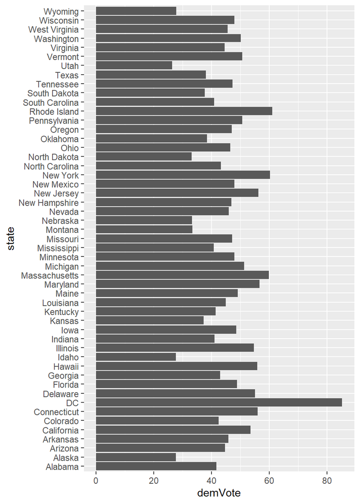

```r
ggplot(data = votedata %>% filter(year == 2000)) +
  geom_col(aes(x = state, y = demVote)) +
  coord_flip()
```

I don’t love the squashed together coordinates, but it’s a display window issue.

So. This is a helpful graph, but it would be *more* helpful if it was ordered. Use `x = reorder(x_variable, y_variable)` in `aes()` to order the x variable by the y variable

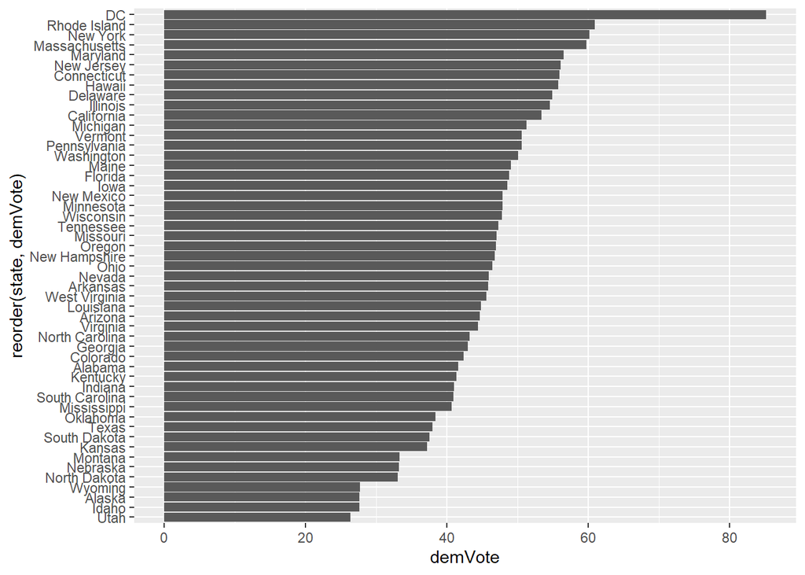

```r
ggplot(data = votedata %>% filter(year == 2000)) +
  geom_col(aes(x = reorder(state, demVote), y = demVote)) +
  coord_flip()
```

So, what if I want to see what the north and south states did different?

start with a facet_wrap using the `south` variable:

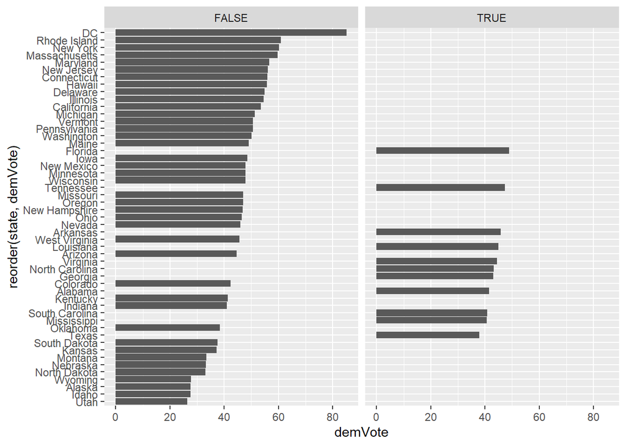

```r
ggplot(votedata %>% filter(year == 2000)) +
  geom_col(aes(x = reorder(state, demVote), y = demVote)) + coord_flip() +
  facet_wrap(~ south)
```

Okay, that’s not great. Lets *color* by south instead.

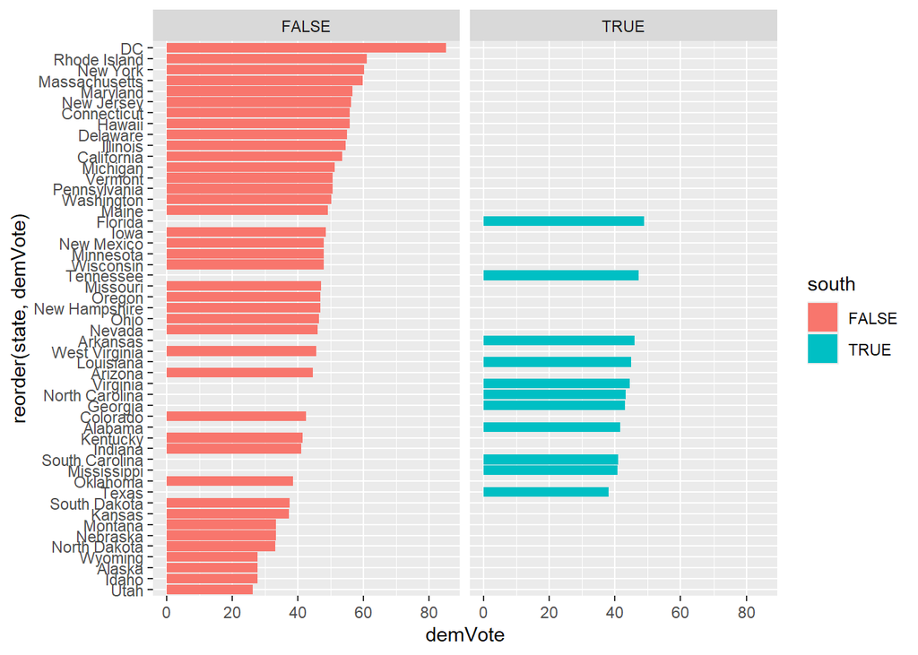

```r
ggplot(votedata %>% filter(year == 2000)) +
  geom_col(aes(x = reorder(state, demVote), y = demVote, fill = south)) + coord_flip() +
  facet_wrap(~ south)
```

I’m a good data scientist, so I want my plot to have a name! and my axes to have lables! Use `labs` to add a title, subtitle, and x and y labels.

```r
ggplot(votedata %>% filter(year == 2000)) +
  geom_col(aes(x = reorder(state, demVote), y = demVote, fill = south)) + coord_flip() +
  labs(title = "Democratic Vote by State in 2000",
       subtitle = "Color based on State location",
       x = "State",
       y = "Democratic Vote Percentage")
```

[output not shown]

You can move the legend with `theme(legend.position = "bottom")`

```r
ggplot(votedata %>% filter(year == 2000)) +
  geom_col(aes(x = reorder(state, demVote), y = demVote, fill = south)) + coord_flip() +
  labs(title = "Democratic Vote by State in 2000",
       subtitle = "Color based on State location",
       x = "State",
       y = "Democratic Vote Percentage") +
  theme(legend.position = "bottom")
```

[output not shown]

What else could we facet by? years! Let’s filter to year in 2008 and 2016, then facet by years.

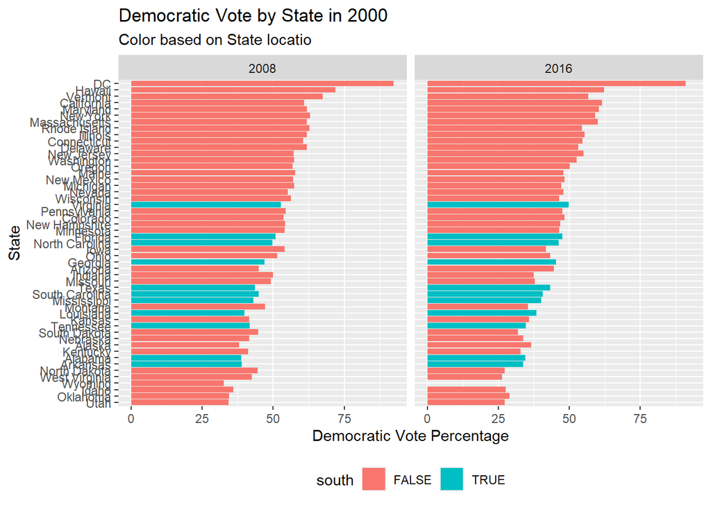

```r
ggplot(votedata %>% filter(year == 2008 | year == 2016)) +
  geom_col(aes(x = reorder(state, demVote), y = demVote, fill = south)) +
  coord_flip() +
  facet_wrap(~ year) +
  labs(title = "Democratic Vote by State in 2000",
       subtitle = "Color based on State locatio",
       x = "State",
       y = "Democratic Vote Percentage") +
  theme(legend.position = "bottom")
```

We need to know who won! We could add a vertical line at 50 for who got more, to indicate the majority of votes. Adding the layer `geom_hline()` adds a horizontal line. (What do you guess `geom_vline()` would do?)

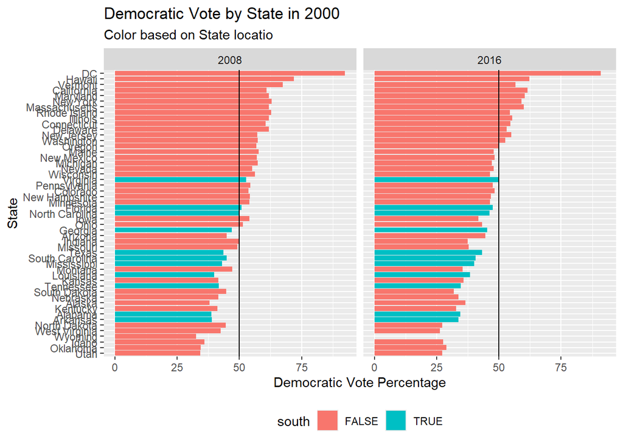

```r
ggplot(votedata %>% filter(year == 2008 | year == 2016)) +
  geom_col(aes(x = reorder(state, demVote), y = demVote, fill = south)) +
  coord_flip() +
  facet_wrap(~ year) +
  labs(title = "Democratic Vote by State in 2000",
       subtitle = "Color based on State locatio",
       x = "State",
       y = "Democratic Vote Percentage") +
  theme(legend.position = "bottom") +
  geom_hline(yintercept = 50)
```

### Getting fancy with a map!

When using geom_polygon or geom_map, you will typically need two data frames:

- one contains the coordinates of each polygon (positions)
- the other the values associated with each polygon (values).

An id variable links the two together.

Run the below code to get a map graph.

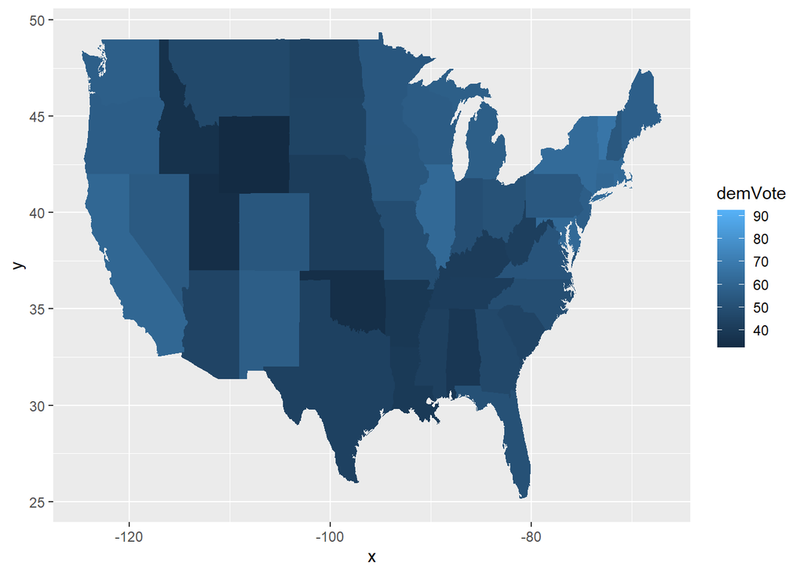

```r
library(maps)
votedata$state <- tolower(votedata$state)  ## states need to be lowercase for linking

states_map <- map_data("state") ## this gives us the lat and long for each point of each state.

map_plot <-  ggplot(data =  votedata %>% filter(year == 2008), aes(map_id = state)) +
    geom_map(aes(fill = demVote), map = states_map) +
    expand_limits(x = states_map$long, y = states_map$lat)
map_plot
```

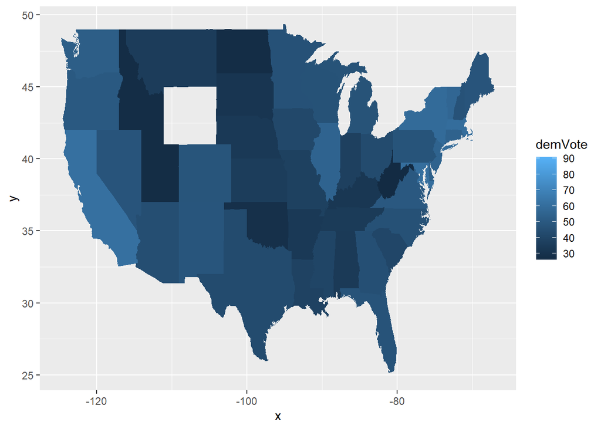

```r
map_plot <-  ggplot(data =  votedata %>% filter(year == 2016), aes(map_id = state)) +
  geom_map(aes(fill = demVote), map = states_map)+
  expand_limits(x = states_map$long, y = states_map$lat)
map_plot
```

What if I want a map that shows which of the states are “south”? What do I change?

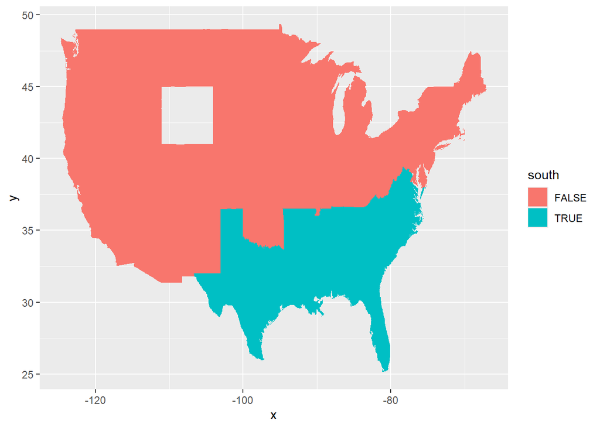

```r
map_plot <-  ggplot(data =  votedata %>% filter(year == 2016), aes(map_id = state)) +
  geom_map(aes(fill = south), map = states_map)+
  expand_limits(x = states_map$long, y = states_map$lat)
map_plot
```

### Some more dplyr practice

I want to know the average democratic vote for N vs S, by year.

First, find the average democratic votes for the north and the south, every year. You’ll need to do a *double* `group_by()` here. You do it in one call of the function.

```r
votedata %>% group_by(south, year) %>% summarise(mean_dem = mean(demVote))
```

```
## # A tibble: 44 × 3
## # Groups:   south [2]
##    south  year mean_dem
##    <lgl> <int>    <dbl>
##  1 FALSE  1932     56.7
##  2 FALSE  1936     59.2
##  3 FALSE  1940     52.8
##  4 FALSE  1944     51.1
##  5 FALSE  1948     50.2
##  6 FALSE  1952     40.9
##  7 FALSE  1956     40.1
##  8 FALSE  1960     48.0
##  9 FALSE  1964     63.0
## 10 FALSE  1968     44.7
## # ℹ 34 more rows
```

Then, let’s plot that! Pipe the result of your group_by and summarize to ggplot and geom_line(), with year on the x axis and your summarized value on the y axis. Color by the `south` variable.

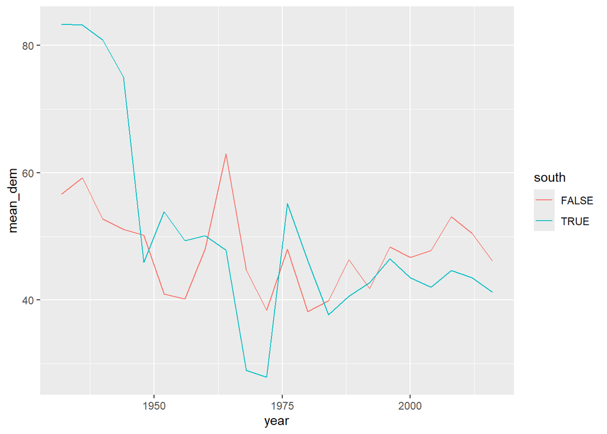

```r
votedata %>%
  group_by(south, year) %>%
  summarise(mean_dem = mean(demVote)) %>%
  ggplot(aes(x = year, y = mean_dem, color = south)) + geom_line()
```

## Layering plots!

Penguins!

```r
library(palmerpenguins)
glimpse(penguins)
```

```
## Rows: 344
## Columns: 8
## $ species           <fct> Adelie, Adelie, Adelie, Adelie, Adelie, Adelie, Adel…
## $ island            <fct> Torgersen, Torgersen, Torgersen, Torgersen, Torgerse…
## $ bill_length_mm    <dbl> 39.1, 39.5, 40.3, NA, 36.7, 39.3, 38.9, 39.2, 34.1, …
## $ bill_depth_mm     <dbl> 18.7, 17.4, 18.0, NA, 19.3, 20.6, 17.8, 19.6, 18.1, …
## $ flipper_length_mm <int> 181, 186, 195, NA, 193, 190, 181, 195, 193, 190, 186…
## $ body_mass_g       <int> 3750, 3800, 3250, NA, 3450, 3650, 3625, 4675, 3475, …
## $ sex               <fct> male, female, female, NA, female, male, female, male…
## $ year              <int> 2007, 2007, 2007, 2007, 2007, 2007, 2007, 2007, 2007…
```

We can use boxplots to visualize the distribution of weight (body_mass_g) within each species:

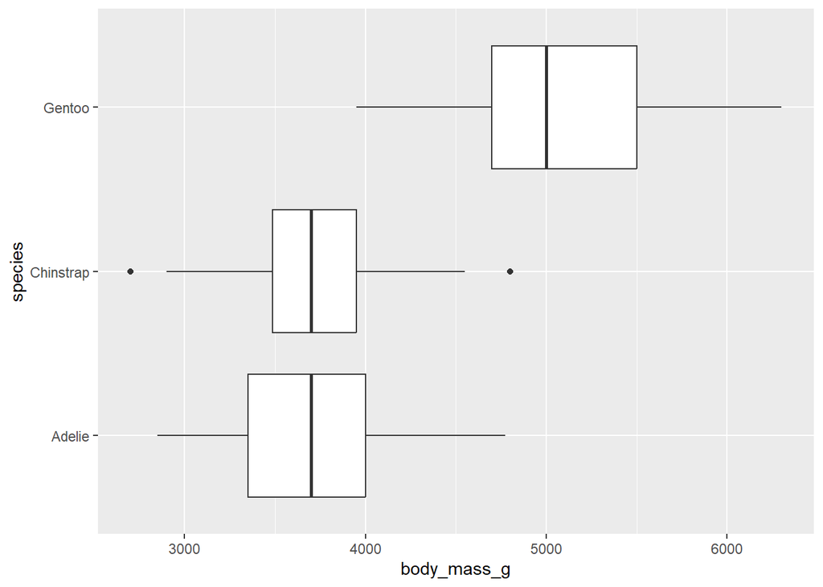

```r
ggplot(penguins, aes(x = body_mass_g, y = species)) + geom_boxplot()
```

What if we also want the points? Layering!! Add a geom_point to your existing boxplot. geom_boxplot + geom_point!

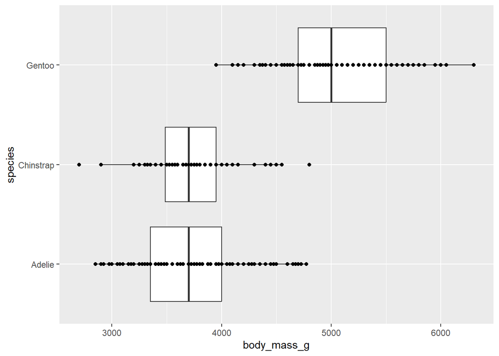

```r
ggplot(penguins, aes(x = body_mass_g, y = species)) + geom_boxplot() + geom_point()
```

But, these are all stacked up… to actually see them, use “geom_jitter” instead of points

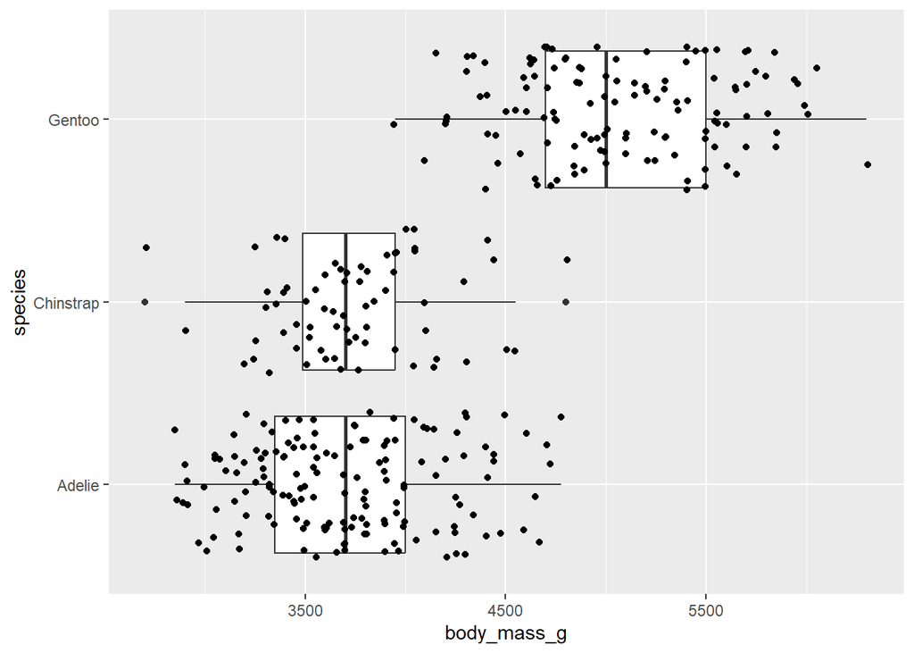

```r
ggplot(penguins, aes(x = body_mass_g, y = species)) + geom_boxplot() + geom_jitter()
```

How to get the boxplots on top? The layers are plotted in the order you give them, so change to geom_point + geom_boxplot. (You might want to change the alpha on the boxplot to be able to see the plots under them)

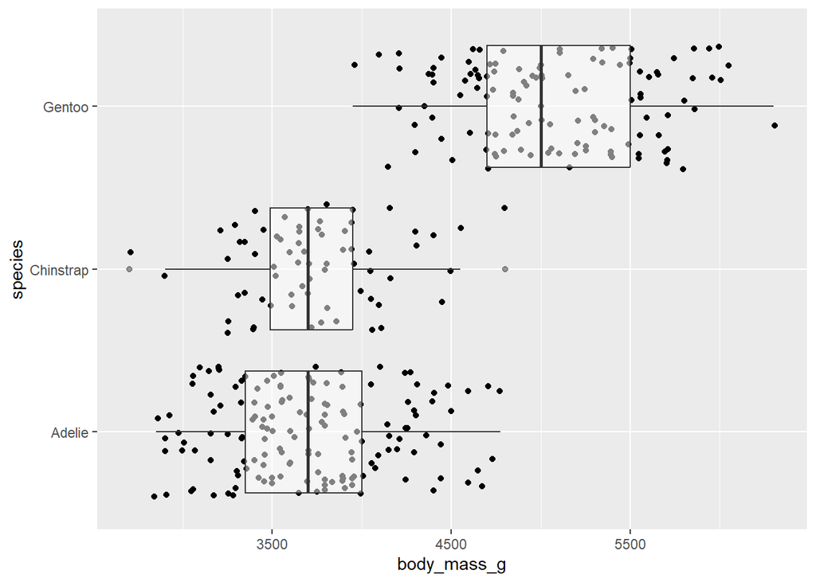

```r
ggplot(penguins, aes(x = body_mass_g, y = species))  + geom_jitter() + geom_boxplot(alpha = 0.5)
```

Maybe let’s try replacing the boxplot with a `geom_violin()`?

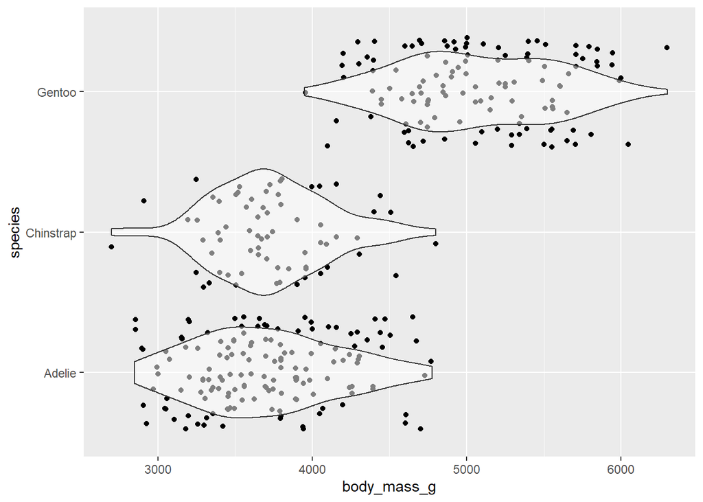

```r
ggplot(penguins, aes(x = body_mass_g, y = species))  + geom_jitter() + geom_violin(alpha = 0.5)
```

## If time: More Practice with Penguins

- Count the number of male and female penguins for each species.
- Find the average penguin mass for each island
- Find the average bill length by sex
- Make a plot of bill_length and bill_depth, but only for the female penguins.
- Make a plot of flipper length and body mass, faceted by island and colored by species.
- Plot the density of the flipper length, colored by sex
- Plot the density of the body mass, colored by year

```r
counting_penguins <- penguins %>%
  group_by(species, sex) %>%
  summarise(count = n(), .groups = 'drop')
counting_penguins
```

```
## # A tibble: 8 × 3
##   species   sex    count
##   <fct>     <fct>  <int>
## 1 Adelie    female    73
## 2 Adelie    male      73
## 3 Adelie    <NA>       6
## 4 Chinstrap female    34
## 5 Chinstrap male      34
## 6 Gentoo    female    58
## 7 Gentoo    male      61
## 8 Gentoo    <NA>       5
```

```r
avg_mass_by_island <- penguins %>%
  group_by(island) %>%
  summarise(average_mass = mean(body_mass_g, na.rm = TRUE))
avg_mass_by_island
```

```
## # A tibble: 3 × 2
##   island    average_mass
##   <fct>            <dbl>
## 1 Biscoe           4716.
## 2 Dream            3713.
## 3 Torgersen        3706.
```

```r
avg_bill_length_by_sex <- penguins %>%
  group_by(sex) %>%
  summarise(average_bill_length = mean(bill_length_mm, na.rm = TRUE))
avg_bill_length_by_sex
```

```
## # A tibble: 3 × 2
##   sex    average_bill_length
##   <fct>                <dbl>
## 1 female                42.1
## 2 male                  45.9
## 3 <NA>                  41.3
```

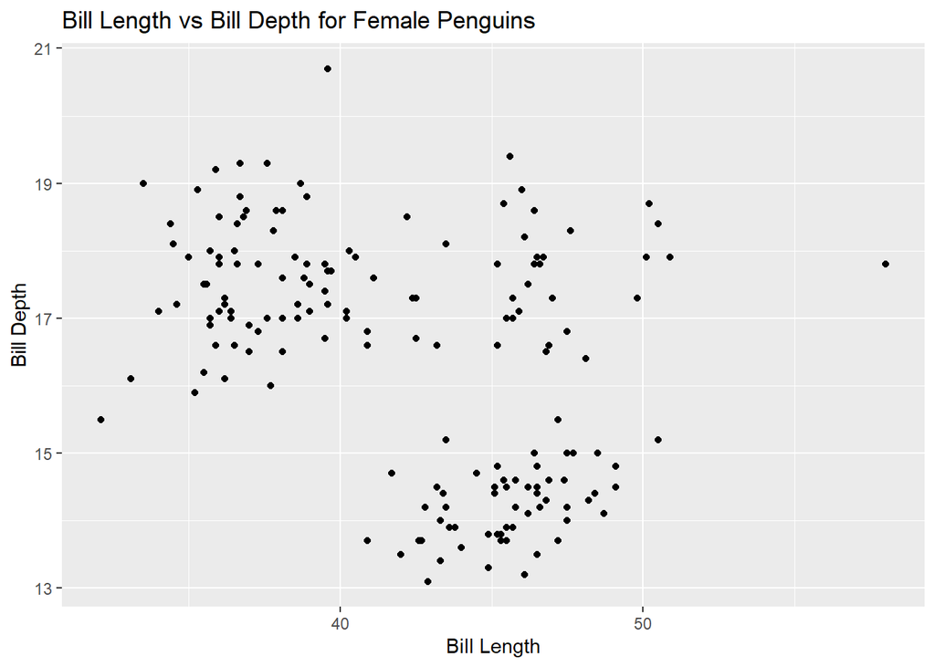

```r
# Female plot of bill_length and bill_depth
female_penguins <- penguins %>% filter(sex == "female")
ggplot(female_penguins, aes(x = bill_length_mm, y = bill_depth_mm)) +
  geom_point() +
  labs(title = "Bill Length vs Bill Depth for Female Penguins",
       x = "Bill Length",
       y = "Bill Depth")
```

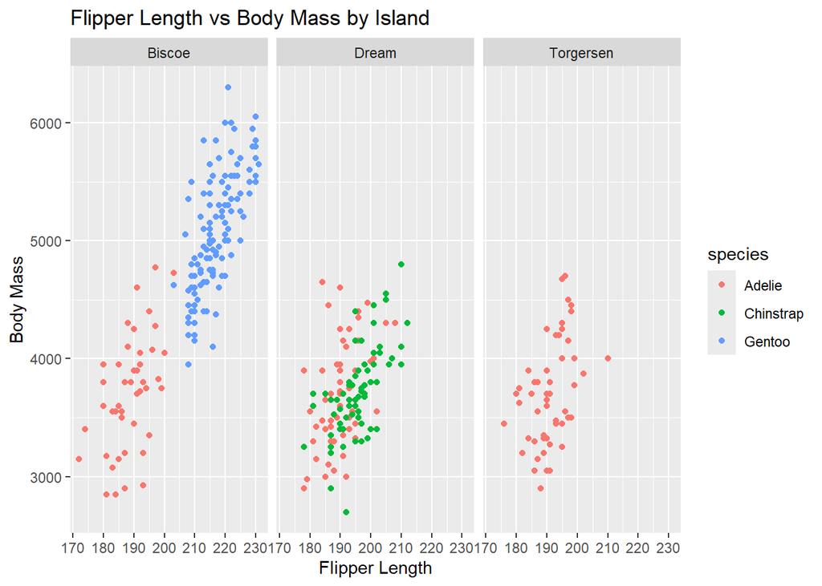

```r
# Plot of flipper length and body mass
ggplot(penguins, aes(x = flipper_length_mm, y = body_mass_g, color = species)) +
  geom_point() +
  facet_wrap(~ island) +
  labs(title = "Flipper Length vs Body Mass by Island",
       x = "Flipper Length",
       y = "Body Mass")
```

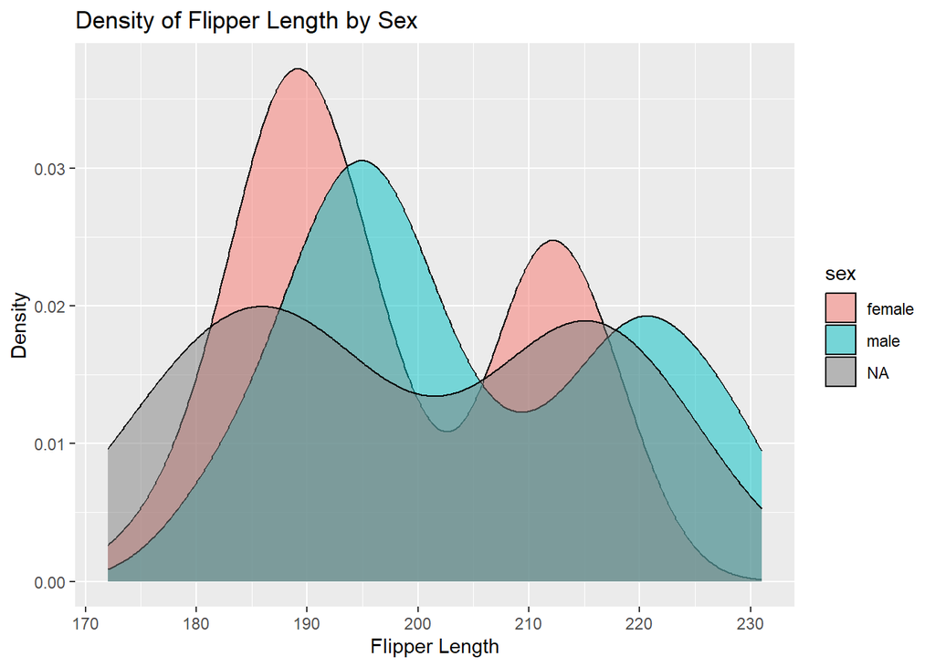

```r
# Density plot of flipper length, colored by sex
ggplot(penguins, aes(x = flipper_length_mm, fill = sex)) +
  geom_density(alpha = 0.5) +
  labs(title = "Density of Flipper Length by Sex",
       x = "Flipper Length",
       y = "Density")
```

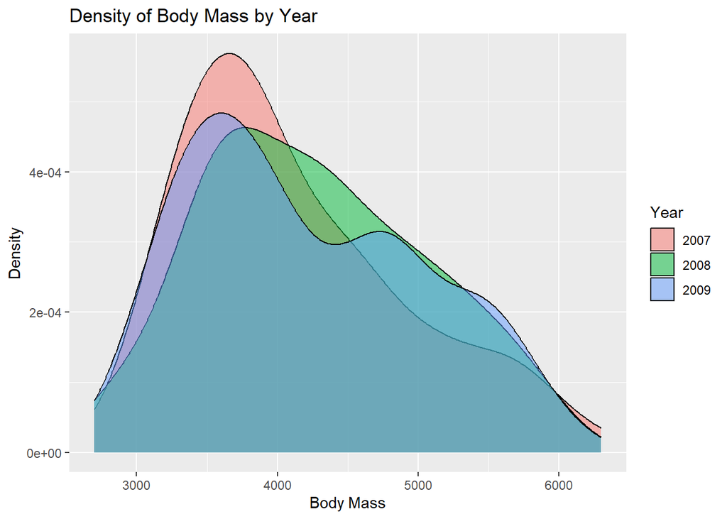

```r
# Density plot of body mass, colored by year
ggplot(penguins, aes(x = body_mass_g, fill = factor(year))) +
  geom_density(alpha = 0.5) +
  labs(title = "Density of Body Mass by Year",
       x = "Body Mass",
       y = "Density",
       fill = "Year")
```